# Data Transformation with dplyr (W6)

2019-10-17

## Why dplyr?

- 上週介紹過篩選 data frame 的方法：`df[<vector 1>, <vector 2>]`。但這種方法有一個缺點：隨著篩選條件越來越多，篩選 data frame 的指令會越來越複雜，變得難以閱讀，例如:

  ```r
  library(tibble)
  df <- as_tibble(iris)

  # How long does it take to understand the command below?
  df[(df$Species == "setosa") & (df$Sepal.Length < 5.8), c("Species", "Sepal.Width")]
  ```

  ```
  #> # A tibble: 49 x 2
  #>    Species Sepal.Width
  #>    <fct>         <dbl>
  #>  1 setosa          3.5
  #>  2 setosa          3
  #>  3 setosa          3.2
  #>  4 setosa          3.1
  #>  5 setosa          3.6
  #>  6 setosa          3.9
  #>  7 setosa          3.4
  #>  8 setosa          3.4
  #>  9 setosa          2.9
  #> 10 setosa          3.1
  #> # … with 39 more rows
  ```

- 套件 `dplyr` 目的就是為了使這個過程變得更加容易：讓處理 data frame 的指令變得直覺易懂。

## 讀取表格式資料 (`.csv`)

- 可使用 RStudio `Environment Pane > Import Dataset > From Text (readr)...`，或直接使用指令：

  ```r
  babynames <- readr::read_csv('babynames.csv')
  babynames
  ```

  ```
  #> # A tibble: 177,780 x 5
  #>     year sex   name        n   prop
  #>    <dbl> <chr> <chr>   <dbl>  <dbl>
  #>  1  1880 M     John     9655 0.0815
  #>  2  1880 M     William  9532 0.0805
  #>  3  1880 M     James    5927 0.0501
  #>  4  1880 M     Charles  5348 0.0452
  #>  5  1880 M     George   5126 0.0433
  #>  6  1880 M     Frank    3242 0.0274
  #>  7  1880 M     Joseph   2632 0.0222
  #>  8  1880 M     Thomas   2534 0.0214
  #>  9  1880 M     Henry    2444 0.0206
  #> 10  1880 M     Robert   2415 0.0204
  #> # … with 177,770 more rows
  ```

  如此便會將外部檔案讀入成 `tibble` (data frame)

## Functions for “isolating data” in dplyr

- `dplyr` 有 2 個重要的函數可以用來取代上週講過得 `[<vector 1> , <vector 2>]`
  - `select()`: 篩選出 data frame 中的**變項 (variables)** (i.e. columns of a data frame)
  - `filter()`: 篩選出 data frame 中特定的**觀察值 (observations)** (i.e. rows of a data frame)
  - `select()` 與 `filter()` 分別取代了 `[<vector 1> , <vector 2>]` 之中的 `vector 2` 與 `vector 1` 的功能。除此之外，dplyr 還有 `arrange()` 可以用來**將觀察值依據某些變項進行排序**。

## `select()`: 篩選出特定變項

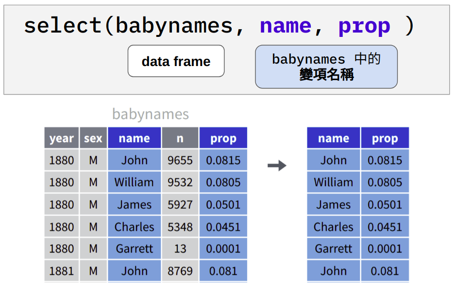

篩選出 `babynames` 中的 `name` 與 `prop` 變項。

```r
library(dplyr)

# select(<data frame>, <variable name in df>, <variable name in df>, ...)
select(babynames, name, prop)  # eqivalent to babynames[, c("name", "prop")]
```

```
#> # A tibble: 177,780 x 2
#>    name      prop
#>    <chr>    <dbl>
#>  1 John    0.0815
#>  2 William 0.0805
#>  3 James   0.0501
#>  4 Charles 0.0452
#>  5 George  0.0433
#>  6 Frank   0.0274
#>  7 Joseph  0.0222
#>  8 Thomas  0.0214
#>  9 Henry   0.0206
#> 10 Robert  0.0204
#> # … with 177,770 more rows
```

### helpers

- `dplyr` 額外提供了一些函數，方便使用者依據**變項名稱的特性**去篩選變項：

  ```r
  iris_ <- as_tibble(iris)
  select(iris_, starts_with('Sepal'))
  ```

  ```
  #> # A tibble: 150 x 2
  #>    Sepal.Length Sepal.Width
  #>           <dbl>       <dbl>
  #>  1          5.1         3.5
  #>  2          4.9         3
  #>  3          4.7         3.2
  #>  4          4.6         3.1
  #>  5          5           3.6
  #>  6          5.4         3.9
  #>  7          4.6         3.4
  #>  8          5           3.4
  #>  9          4.4         2.9
  #> 10          4.9         3.1
  #> # … with 140 more rows
  ```

  ```r
  select(iris_, ends_with('Width'))
  ```

  ```
  #> # A tibble: 150 x 2
  #>    Sepal.Width Petal.Width
  #>          <dbl>       <dbl>
  #>  1         3.5         0.2
  #>  2         3           0.2
  #>  3         3.2         0.2
  #>  4         3.1         0.2
  #>  5         3.6         0.2
  #>  6         3.9         0.4
  #>  7         3.4         0.3
  #>  8         3.4         0.2
  #>  9         2.9         0.2
  #> 10         3.1         0.1
  #> # … with 140 more rows
  ```

  ```r
  select(iris_, contains('.'))
  ```

  ```
  #> # A tibble: 150 x 4
  #>    Sepal.Length Sepal.Width Petal.Length Petal.Width
  #>           <dbl>       <dbl>        <dbl>       <dbl>
  #>  1          5.1         3.5          1.4         0.2
  #>  2          4.9         3            1.4         0.2
  #>  3          4.7         3.2          1.3         0.2
  #>  4          4.6         3.1          1.5         0.2
  #>  5          5           3.6          1.4         0.2
  #>  6          5.4         3.9          1.7         0.4
  #>  7          4.6         3.4          1.4         0.3
  #>  8          5           3.4          1.5         0.2
  #>  9          4.4         2.9          1.4         0.2
  #> 10          4.9         3.1          1.5         0.1
  #> # … with 140 more rows
  ```

  ```r
  df <- tibble(x_1 = 1:10, x_2 = 11:20, x_3 = 21:30, x_4 = 31:40, x_5 = 41:50)
  select(df, num_range("x_", 2:4))
  ```

  ```
  #> # A tibble: 10 x 3
  #>      x_2   x_3   x_4
  #>    <int> <int> <int>
  #>  1    11    21    31
  #>  2    12    22    32
  #>  3    13    23    33
  #>  4    14    24    34
  #>  5    15    25    35
  #>  6    16    26    36
  #>  7    17    27    37
  #>  8    18    28    38
  #>  9    19    29    39
  #> 10    20    30    40
  ```

  ```r
  # You can still quote the variable names
  select(df, "x_1", "x_2", "x_3")
  ```

  ```
  #> # A tibble: 10 x 3
  #>      x_1   x_2   x_3
  #>    <int> <int> <int>
  #>  1     1    11    21
  #>  2     2    12    22
  #>  3     3    13    23
  #>  4     4    14    24
  #>  5     5    15    25
  #>  6     6    16    26
  #>  7     7    17    27
  #>  8     8    18    28
  #>  9     9    19    29
  #> 10    10    20    30
  ```

  ```r
  # So `select()` can be mixed with base R's `paste0()`
  select(df, paste0("x_", 1:3))
  ```

  ```
  #> # A tibble: 10 x 3
  #>      x_1   x_2   x_3
  #>    <int> <int> <int>
  #>  1     1    11    21
  #>  2     2    12    22
  #>  3     3    13    23
  #>  4     4    14    24
  #>  5     5    15    25
  #>  6     6    16    26
  #>  7     7    17    27
  #>  8     8    18    28
  #>  9     9    19    29
  #> 10    10    20    30
  ```

## `filter()`: 篩選出特定觀察值

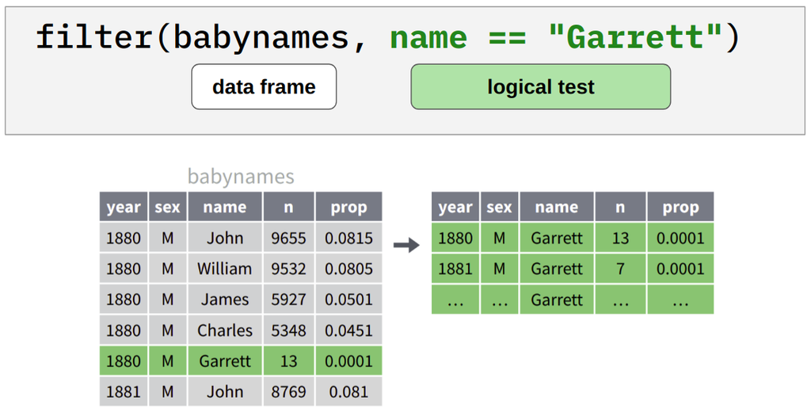

篩選出 `babynames` 中的 `name` 為 “Garrett” 的觀察值。

```r
# filter(<data frame>, <logical test on variable>, <logical test on variable>, ...)
filter(babynames, name == "Garrett")
```

```
#> # A tibble: 13 x 5
#>     year sex   name        n       prop
#>    <dbl> <chr> <chr>   <dbl>      <dbl>
#>  1  1880 M     Garrett    13 0.000110
#>  2  1881 M     Garrett     7 0.0000646
#>  3  1882 M     Garrett    15 0.000123
#>  4  1883 M     Garrett    13 0.000116
#>  5  1884 M     Garrett    15 0.000122
#>  6  1885 M     Garrett     9 0.0000776
#>  7  2013 M     Garrett  1613 0.000800
#>  8  2013 F     Garrett     5 0.0000026
#>  9  2014 M     Garrett  1562 0.000764
#> 10  2014 F     Garrett     6 0.00000307
#> 11  2015 M     Garrett  1349 0.000662
#> 12  2016 M     Garrett  1146 0.000568
#> 13  2017 M     Garrett  1056 0.000538
```

```r
filter(babynames, (name == "Garrett") & (year < 1885))
```

```
#> # A tibble: 5 x 5
#>    year sex   name        n      prop
#>   <dbl> <chr> <chr>   <dbl>     <dbl>
#> 1  1880 M     Garrett    13 0.000110
#> 2  1881 M     Garrett     7 0.0000646
#> 3  1882 M     Garrett    15 0.000123
#> 4  1883 M     Garrett    13 0.000116
#> 5  1884 M     Garrett    15 0.000122
```

```r
filter(babynames, name == "Garrett", year < 1885)  # equivalent to the previous command
```

```
#> # A tibble: 5 x 5
#>    year sex   name        n      prop
#>   <dbl> <chr> <chr>   <dbl>     <dbl>
#> 1  1880 M     Garrett    13 0.000110
#> 2  1881 M     Garrett     7 0.0000646
#> 3  1882 M     Garrett    15 0.000123
#> 4  1883 M     Garrett    13 0.000116
#> 5  1884 M     Garrett    15 0.000122
```

## `arrange()`: 重新排序觀察值

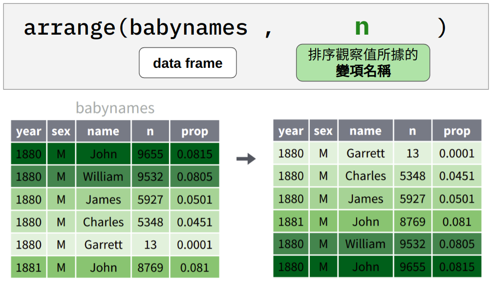

依據變項 `n` 的大小由小至大排序 `babynames` 中的觀察值。

```r
#arrange(<data frame>, <variable name in df>, <variable name in df>, ...)
arrange(babynames, n)
```

```
#> # A tibble: 177,780 x 5
#>     year sex   name         n      prop
#>    <dbl> <chr> <chr>    <dbl>     <dbl>
#>  1  1880 M     Ab           5 0.0000422
#>  2  1880 M     Abbott       5 0.0000422
#>  3  1880 M     Agustus      5 0.0000422
#>  4  1880 M     Albertus     5 0.0000422
#>  5  1880 M     Almer        5 0.0000422
#>  6  1880 M     Alphonso     5 0.0000422
#>  7  1880 M     Alvia        5 0.0000422
#>  8  1880 M     Artie        5 0.0000422
#>  9  1880 M     Arvid        5 0.0000422
#> 10  1880 M     Ashby        5 0.0000422
#> # … with 177,770 more rows
```

```r
# 由大至小排序 (降冪)
arrange(babynames, desc(n))
```

```
#> # A tibble: 177,780 x 5
#>     year sex   name       n    prop
#>    <dbl> <chr> <chr>  <dbl>   <dbl>
#>  1  2013 F     Sophia 21213 0.0110
#>  2  2013 F     Emma   20936 0.0109
#>  3  2014 F     Emma   20924 0.0107
#>  4  2015 F     Emma   20435 0.0105
#>  5  2014 F     Olivia 19791 0.0101
#>  6  2017 F     Emma   19738 0.0105
#>  7  2015 F     Olivia 19669 0.0101
#>  8  2015 M     Noah   19613 0.00962
#>  9  2016 F     Emma   19471 0.0101
#> 10  2016 F     Olivia 19327 0.0100
#> # … with 177,770 more rows
```

```r
# Order first by `year` then by `name`
arrange(babynames, year, name)
```

```
#> # A tibble: 177,780 x 5
#>     year sex   name        n      prop
#>    <dbl> <chr> <chr>   <dbl>     <dbl>
#>  1  1880 M     Aaron     102 0.000861
#>  2  1880 M     Ab          5 0.0000422
#>  3  1880 F     Abbie      71 0.000727
#>  4  1880 M     Abbott      5 0.0000422
#>  5  1880 F     Abby        6 0.0000615
#>  6  1880 M     Abe        50 0.000422
#>  7  1880 M     Abel        9 0.0000760
#>  8  1880 F     Abigail    12 0.000123
#>  9  1880 M     Abner      27 0.000228
#> 10  1880 M     Abraham    81 0.000684
#> # … with 177,770 more rows
```

```r
# Order first by `name` then by `year`
arrange(babynames, name, year)
```

```
#> # A tibble: 177,780 x 5
#>     year sex   name      n       prop
#>    <dbl> <chr> <chr> <dbl>      <dbl>
#>  1  2013 M     Aaban    14 0.00000694
#>  2  2014 M     Aaban    16 0.00000783
#>  3  2015 M     Aaban    15 0.00000736
#>  4  2016 M     Aaban     9 0.00000446
#>  5  2017 M     Aaban    11 0.0000056
#>  6  2014 F     Aabha     9 0.00000461
#>  7  2015 F     Aabha     7 0.0000036
#>  8  2016 F     Aabha     7 0.00000363
#>  9  2016 M     Aabid     5 0.00000248
#> 10  2016 M     Aabir     5 0.00000248
#> # … with 177,770 more rows
```

1. Pop quiz 3: answer

   ```r
   girls2017 <- filter(babynames, year == 2017, sex == "F")
   girls2017 <- select(girls2017, name, n)
   girls2017 <- arrange(girls2017, desc(n))
   girls2017
   ```

## `%>%`: Connecting multiple dplyr functions together

- `dplyr` 的函數**一次只能做一件事情**:`select()` 只能用來篩選變項、`filter()` 只能用來篩選觀察值、`arrange()` 只能用來排序資料。但資料整理的過程中往往需要**一次做很多事情**，例如，可能需要在篩選完觀察值之後再進行排序。如果每次呼叫完一個函數就必須將結果儲存在一個變項，會讓整理資料的過程變得很麻煩，例如：

  ```r
  girls2017 <- filter(babynames, year == 2017, sex == "F")
  girls2017 <- select(girls2017, name, n)
  girls2017 <- arrange(girls2017, desc(n))
  girls2017
  ```

  ```
  #> # A tibble: 18,309 x 2
  #>    name          n
  #>    <chr>     <dbl>
  #>  1 Emma      19738
  #>  2 Olivia    18632
  #>  3 Ava       15902
  #>  4 Isabella  15100
  #>  5 Sophia    14831
  #>  6 Mia       13437
  #>  7 Charlotte 12893
  #>  8 Amelia    11800
  #>  9 Evelyn    10675
  #> 10 Abigail   10551
  #> # … with 18,299 more rows
  ```

- `dplyr` (精確地說是 `magrittr`) 因此提供了一種特殊的 binary operator `%>%`，讓使用者可以將位在 `%>%` **左側**之表達式的執行結果 (回傳值) 做為位在 `%>%` **右側**之函數的**第一個輸入值 (引數, argument)**：

  ```r
  # Two equivalent expressions
  filter(babynames, year == 2017, sex == "F")

  cat('\n\n')  # 讓印出結果比較好看

  babynames %>% filter(year == 2017, sex == "F")
  ```

  ```
  #> # A tibble: 18,309 x 5
  #>     year sex   name          n    prop
  #>    <dbl> <chr> <chr>     <dbl>   <dbl>
  #>  1  2017 F     Emma      19738 0.0105
  #>  2  2017 F     Olivia    18632 0.00994
  #>  3  2017 F     Ava       15902 0.00848
  #>  4  2017 F     Isabella  15100 0.00805
  #>  5  2017 F     Sophia    14831 0.00791
  #>  6  2017 F     Mia       13437 0.00717
  #>  7  2017 F     Charlotte 12893 0.00688
  #>  8  2017 F     Amelia    11800 0.00629
  #>  9  2017 F     Evelyn    10675 0.00569
  #> 10  2017 F     Abigail   10551 0.00563
  #> # … with 18,299 more rows
  #>
  #>
  #> # A tibble: 18,309 x 5
  #>     year sex   name          n    prop
  #>    <dbl> <chr> <chr>     <dbl>   <dbl>
  #>  1  2017 F     Emma      19738 0.0105
  #>  2  2017 F     Olivia    18632 0.00994
  #>  3  2017 F     Ava       15902 0.00848
  #>  4  2017 F     Isabella  15100 0.00805
  #>  5  2017 F     Sophia    14831 0.00791
  #>  6  2017 F     Mia       13437 0.00717
  #>  7  2017 F     Charlotte 12893 0.00688
  #>  8  2017 F     Amelia    11800 0.00629
  #>  9  2017 F     Evelyn    10675 0.00569
  #> 10  2017 F     Abigail   10551 0.00563
  #> # … with 18,299 more rows
  ```

  如此便可將整理資料的過程改寫成一條「由一個個函數串成的」指令，如下

  ```r
  babynames %>%
      filter(year == 2017, sex == "F") %>%
      select(name, n) %>%
      arrange(desc(n))
  ```

  ```
  #> # A tibble: 18,309 x 2
  #>    name          n
  #>    <chr>     <dbl>
  #>  1 Emma      19738
  #>  2 Olivia    18632
  #>  3 Ava       15902
  #>  4 Isabella  15100
  #>  5 Sophia    14831
  #>  6 Mia       13437
  #>  7 Charlotte 12893
  #>  8 Amelia    11800
  #>  9 Evelyn    10675
  #> 10 Abigail   10551
  #> # … with 18,299 more rows
  ```

## Functions for “deriving information” in dplyr

- 上文介紹的內容是關於「如何篩選或排序既有的資料」。但有時候，我們需要從既有的資料去**產出新的資料**，例如根據既有資料的某些變項計算出新的變項，或是對既有資料做出一些摘要統計。面對這些需求，`dplyr` 提供了 2 個重要的函數：
  1. `mutate()`: 在 data frame 裡建立一個新的變項
  2. `summarise()`: 對 data frame 裡的變項進行摘要，例如，計算某個變項的**算術平均數**、**最大(小)值**、**變異數**等
     - `group_by()` 是 `dplyr` 中常與 `summarise()` 搭配使用的函數，其功能是**將觀察值依據某些「類別變項」進行分類**，如此 `summarise()` 就可依據分組後的結果去計算出**各個組別內變項的摘要**。例如，我們可以先使用 `group_by()` 將 `babynames` 的觀察值依據性別 (`sex`) 進行分類，再使用 `summarise()` 計算出這兩個性別的姓名 (`name`) 的數量。

## `mutate()`: 建立新變項

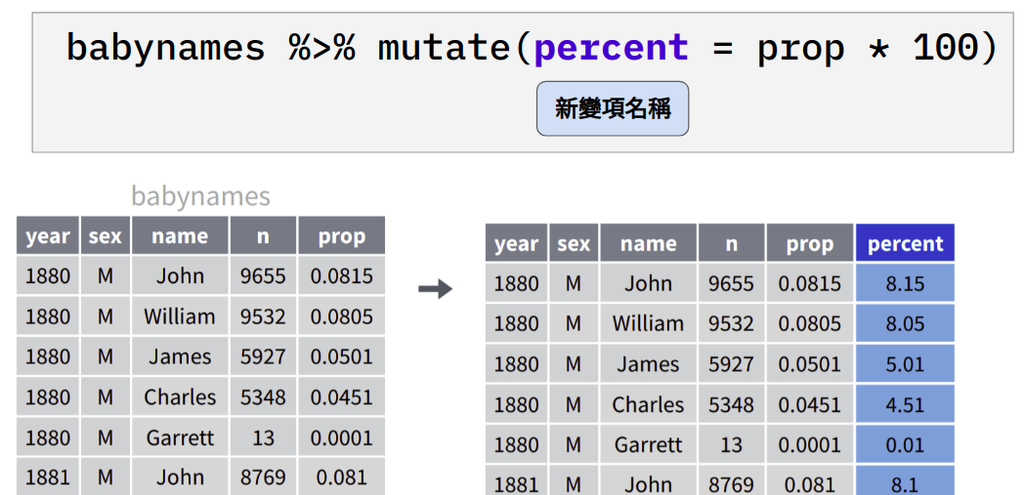

依據變項 `prop` 製造新變項 `percent`。

- `mutate()` 背後運作的原理是 R 的向量式運算，亦即，它是以一個變項 (i.e. 向量) 當作操作的單元。因此，用於 `mutate()` 內的函數必須是所謂的 “**vectorized function**”：vectorized function 是指可接受一個或多個 vector 當作輸入值，並且會回傳**長度相等的 vector**的函數。

```r
babynames %>% mutate(percent = prop*100)
```

```
#> # A tibble: 177,780 x 6
#>     year sex   name        n   prop percent
#>    <dbl> <chr> <chr>   <dbl>  <dbl>   <dbl>
#>  1  1880 M     John     9655 0.0815    8.15
#>  2  1880 M     William  9532 0.0805    8.05
#>  3  1880 M     James    5927 0.0501    5.01
#>  4  1880 M     Charles  5348 0.0452    4.52
#>  5  1880 M     George   5126 0.0433    4.33
#>  6  1880 M     Frank    3242 0.0274    2.74
#>  7  1880 M     Joseph   2632 0.0222    2.22
#>  8  1880 M     Thomas   2534 0.0214    2.14
#>  9  1880 M     Henry    2444 0.0206    2.06
#> 10  1880 M     Robert   2415 0.0204    2.04
#> # … with 177,770 more rows
```

```r
babynames %>% mutate(sex2 = if_else(sex == "F", "female", "male"))
```

```
#> # A tibble: 177,780 x 6
#>     year sex   name        n   prop sex2
#>    <dbl> <chr> <chr>   <dbl>  <dbl> <chr>
#>  1  1880 M     John     9655 0.0815 male
#>  2  1880 M     William  9532 0.0805 male
#>  3  1880 M     James    5927 0.0501 male
#>  4  1880 M     Charles  5348 0.0452 male
#>  5  1880 M     George   5126 0.0433 male
#>  6  1880 M     Frank    3242 0.0274 male
#>  7  1880 M     Joseph   2632 0.0222 male
#>  8  1880 M     Thomas   2534 0.0214 male
#>  9  1880 M     Henry    2444 0.0206 male
#> 10  1880 M     Robert   2415 0.0204 male
#> # … with 177,770 more rows
```

## `summarise()`: 對變項進行摘要

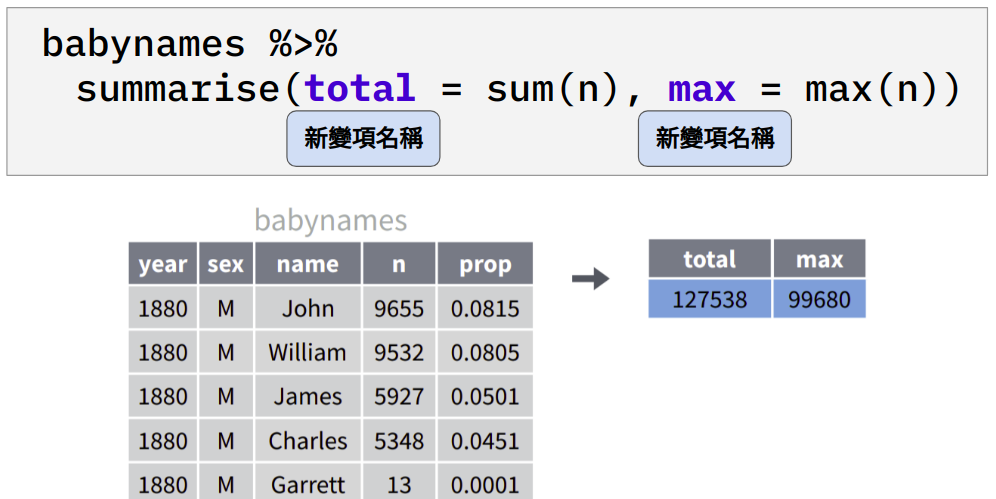

對變項 `n` 進行摘要 (計算總和與最大值)，並將摘要的結果儲存於兩個新變項 `total` 與 `max`。

```r
babynames %>% summarise(total = sum(n), max = max(n))
```

```
#> # A tibble: 1 x 2
#>      total   max
#>      <dbl> <dbl>
#> 1 19538552 21213
```

```r
babynames %>% summarise(num_of_rows = n(), num_of_names = n_distinct(name))
```

```
#> # A tibble: 1 x 2
#>   num_of_rows num_of_names
#>         <int>        <int>
#> 1      177780        45953
```

### `group_by()`: 先分類再摘要

```r
pollution <- tibble::tribble(
       ~city,   ~size, ~amount,
  "New York", "large",      23,
  "New York", "small",      14,
    "London", "large",      22,
    "London", "small",      16,
   "Beijing", "large",      121,
   "Beijing", "small",      56
)
pollution
```

```
#> # A tibble: 6 x 3
#>   city     size  amount
#>   <chr>    <chr>  <dbl>
#> 1 New York large     23
#> 2 New York small     14
#> 3 London   large     22
#> 4 London   small     16
#> 5 Beijing  large    121
#> 6 Beijing  small     56
```

```r
pollution %>%
  group_by(city) %>%
    summarise(mean = mean(amount),
              sum = sum(amount),
              count = n())
```

```
#> # A tibble: 3 x 4
#>   city      mean   sum count
#>   <chr>    <dbl> <dbl> <int>
#> 1 Beijing   88.5   177     2
#> 2 London    19      38     2
#> 3 New York  18.5    37     2
```

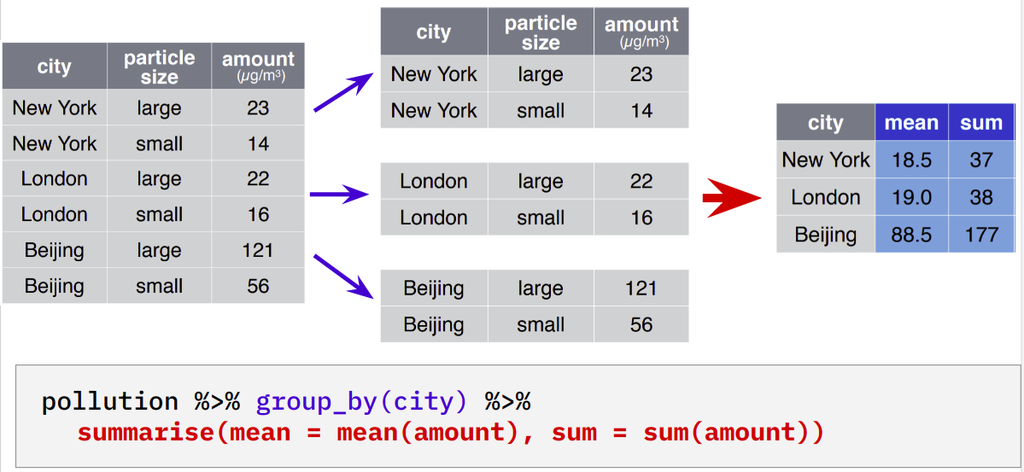

先將 `pollution` 的觀察值依據變項 `city` 分成 3 組，再各自對 3 組進行摘要 (計算污染量平均與總和) 求得之摘要表。

```r
pollution %>%
  group_by(city, size) %>%
  summarise(mean = mean(amount),
            sum = sum(amount),
              count = n())
```

```
#> # A tibble: 6 x 5
#> # Groups:   city [3]
#>   city     size   mean   sum count
#>   <chr>    <chr> <dbl> <dbl> <int>
#> 1 Beijing  large   121   121     1
#> 2 Beijing  small    56    56     1
#> 3 London   large    22    22     1
#> 4 London   small    16    16     1
#> 5 New York large    23    23     1
#> 6 New York small    14    14     1
```